# presentation-live

## Mají širší korunní lístky kosatců také větší délku — a pokud ano, o kolik?

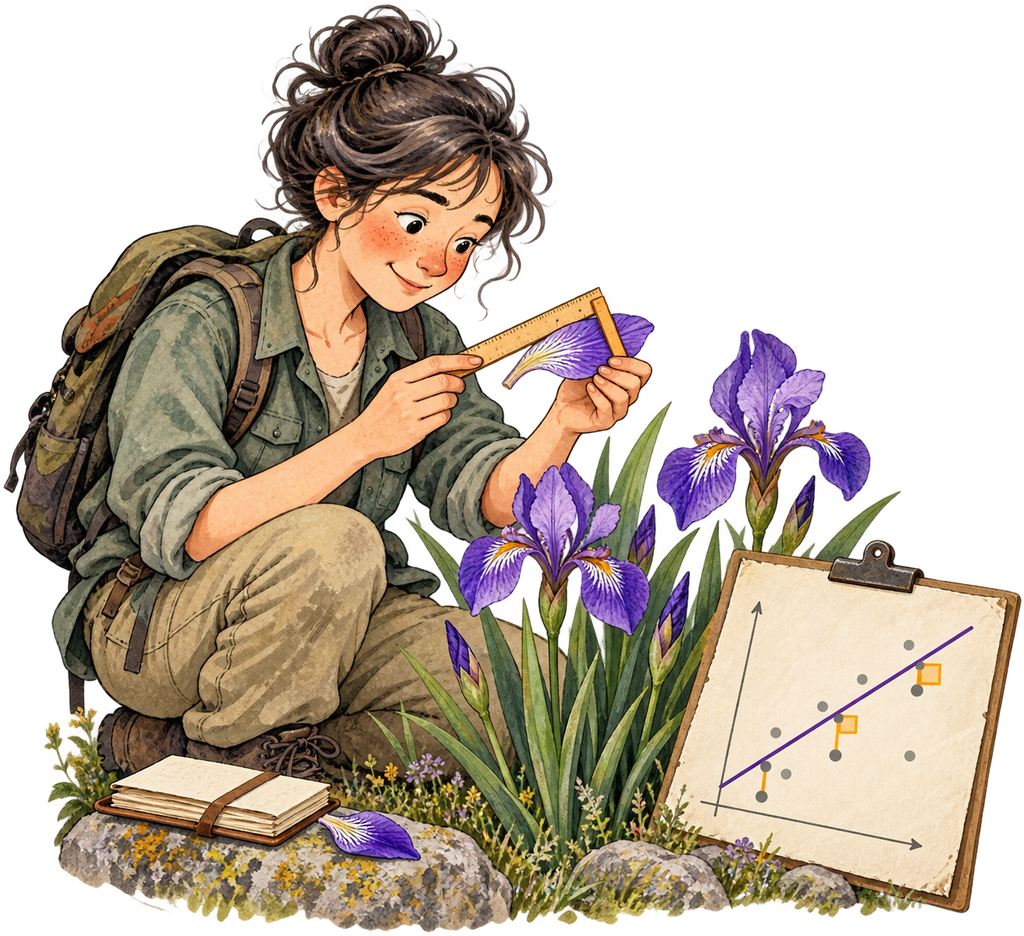

BIOSTATISTIKA

L03

Lineární model s jedním numerickým prediktorem

cuni-natur-biostatistics.github.io/materialy.html

Ilustrace vytvořená pomocí AI.

## Jakou délku odhadneme z naměřené šířky?

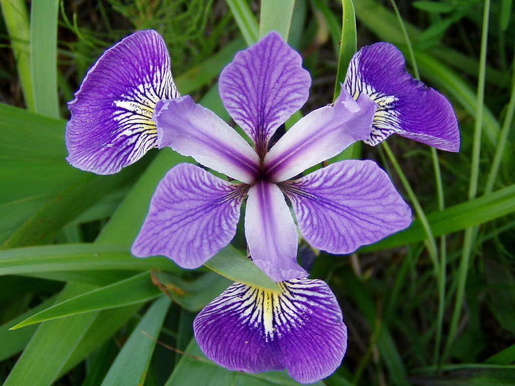

Biologická otázka

**Mají širší korunní lístky kosatců také větší délku — a pokud ano, o kolik?**

Co budeme sledovat

**150 květů**

šířka a délka korunního lístku v centimetrech

Foto: [Danielle Langlois / Wikimedia Commons](https://commons.wikimedia.org/wiki/File:Iris_versicolor_4.jpg), CC BY-SA 3.0

## Co si pamatujete z minulé lekce?

Odpovězte samostatně na tři krátké otázky. Potom společně projdeme správné odpovědi.

## Máme délku ploutve a tělesnou hmotnost každého tučňáka. Který graf je vhodný jako první pohled na jejich vztah?

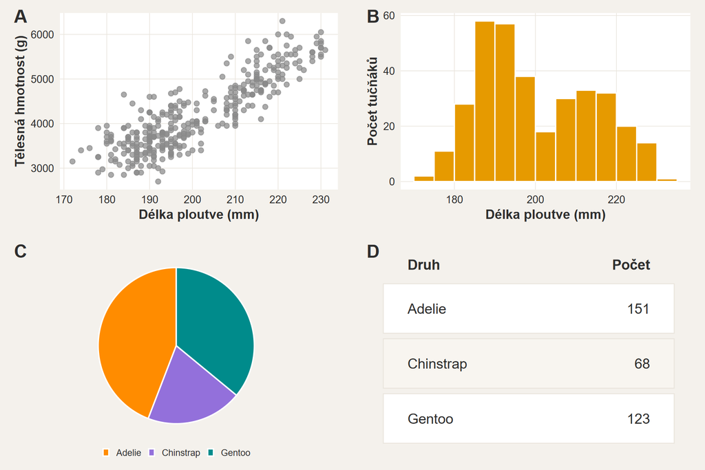

- Bodový graf
- Jeden histogram
- Koláčový graf
- Tabulka četností kategorií

Správná odpověď: Bodový graf

Obě proměnné jsou číselné a každá dvojice měření patří jednomu tučňákovi. Bodový graf zachová obě hodnoty i jejich párování.

## Jaký směr vztahu vidíme v bodovém grafu délky ploutve a tělesné hmotnosti?

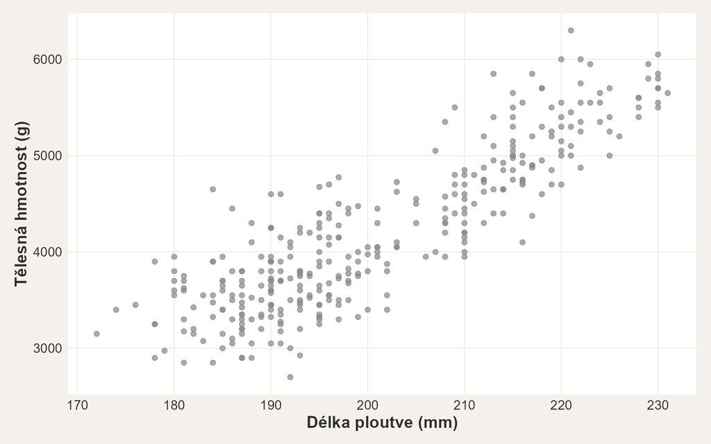

- Převážně klesající
- Bez viditelného směru
- Graf ukazuje pouze jednu proměnnou
- Převážně rostoucí

Správná odpověď: Převážně rostoucí

Tučňáci s delší ploutví bývají v tomto souboru těžší. Body proto tvoří převážně rostoucí oblak.

## Které tvrzení odpovídá tomu, co z tohoto pozorovacího grafu smíme vyvodit?

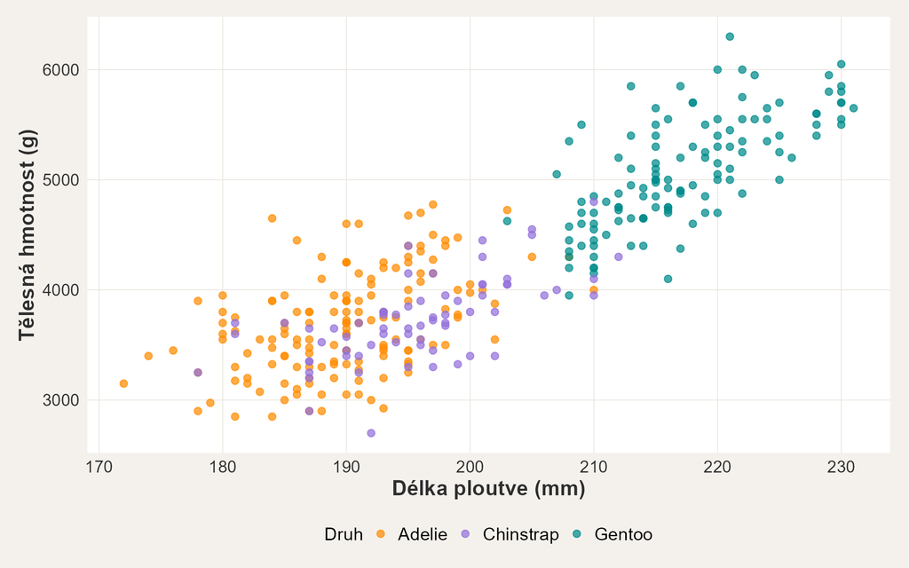

- Delší ploutev způsobuje vyšší tělesnou hmotnost.
- Tělesná hmotnost způsobuje růst ploutve.
- Délka ploutve a tělesná hmotnost spolu v těchto datech souvisejí.
- Druh tučňáka nemůže vztah ovlivnit.

Správná odpověď: Délka ploutve a tělesná hmotnost spolu v těchto datech souvisejí.

Graf podporuje tvrzení o asociaci v pozorovaných datech. Sám neurčuje příčinu ani nevylučuje další proměnné.

## Výsledky učení

Po absolvování této přednášky budete schopni:

- převést biologickou otázku na vztah mezi odezvou a prediktorem
- fitovat `lm(odezva ~ prediktor)` a interpretovat směr i velikost efektu
- vysvětlit residuum jako rozdíl mezi naměřenou a odhadnutou hodnotou
- číst graf residuí a rozpoznat v něm zbývající vzor

# Dvě měření, dvě role

## Co chceme zjistit ze známé šířky?

V minulé lekci jsme popsali vztah délky ploutve a hmotnosti tučňáků. U kosatců se ptáme: **o kolik delší korunní lístek očekáváme u květu, jehož lístek je o 1 cm širší?**

## Co přidá model?

Vztah dvou měření

- vztah zobrazit
- popsat jeho směr
- shrnout jeho těsnost korelací

Délka podle známé šířky

O kolik se typicky liší délka dvou květů, jejichž šířky se liší o 1 cm?

Model vyjádří velikost efektu v původních jednotkách. Přesnost odhadu zůstává otevřená.

## Jedna přímka shrnuje mnoho květů

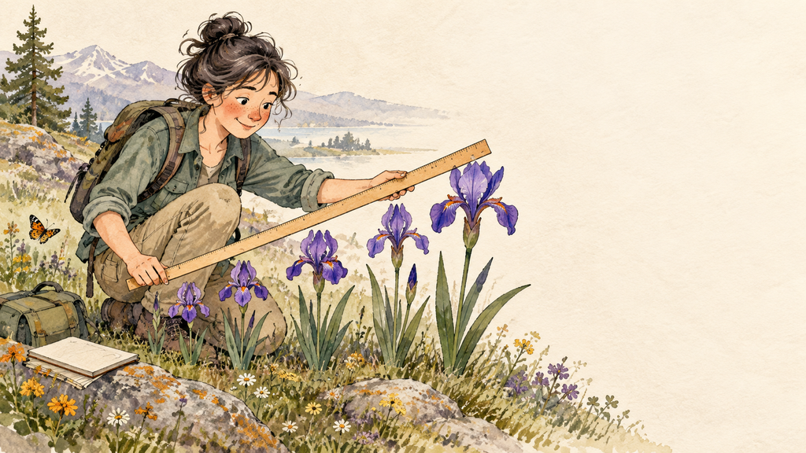

Ilustrační obraz vytvořen AI.

Modelová přímka data nenahrazuje. Stručně popisuje jejich systematický vztah.

## Která proměnná má kterou roli?

Otázka

Na jednom korunním lístku známe jedno měření a druhé podle něj odhadujeme. Které měření bude **neznámé, odhadované**?

**A)** šířka korunního lístku

**B)** délka korunního lístku

Zvolte A/B a zdůvodněte svou volbu sousedovi.

Odhadovanou délku nazýváme odezva, známou šířku prediktor.

## Dvě měření každého květu

| Květ | Šířka (cm) | Délka (cm) | Druh |
| --- | --- | --- | --- |
| 1 | 0,2 | 1,3 | setosa |
| 2 | 1,0 | 3,7 | versicolor |
| 3 | 1,8 | 5,5 | virginica |
| 4 | 2,5 | 6,0 | virginica |

Jeden řádek = jeden květ · dvě numerická měření · druh jako kategorie

Celá data

150 květů · 0 chybějících hodnot

Šířky 0,1–2,5 cm · délky 1–6,9 cm

## Jaký vztah vidíte?

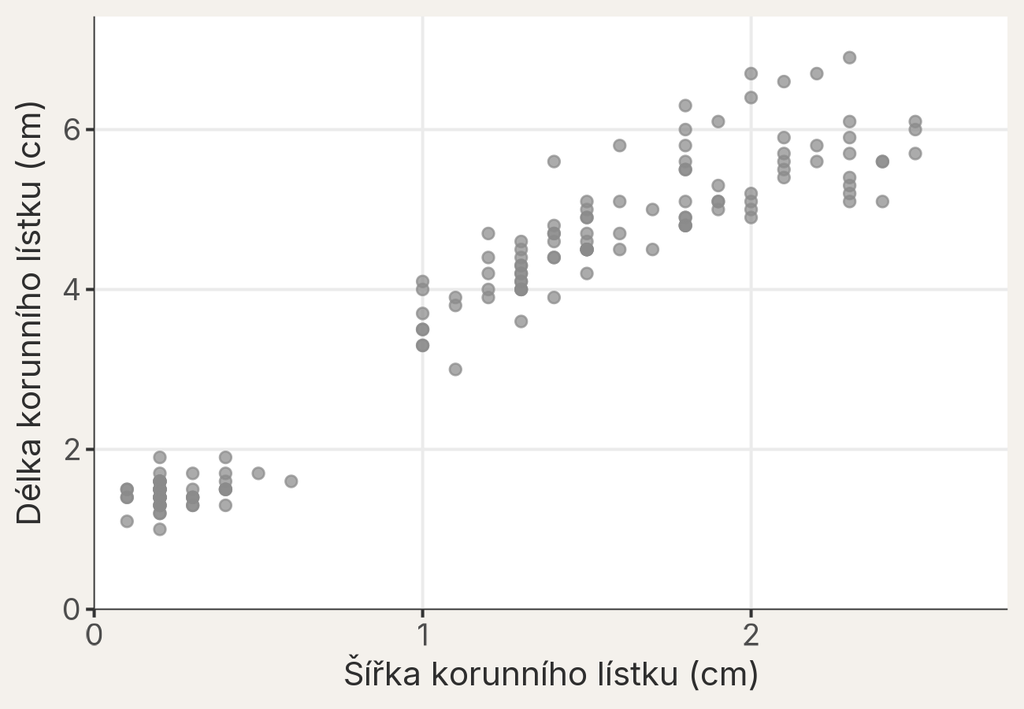

Vyberte nejlepší popis

**A)** bez zřetelného vztahu

**B)** přibližně lineární růst

**C)** výrazně zakřivený růst

Zvolte A/B/C a zdůvodněte odpověď podle bodů v grafu.

## Co z tohoto grafu můžeme říct?

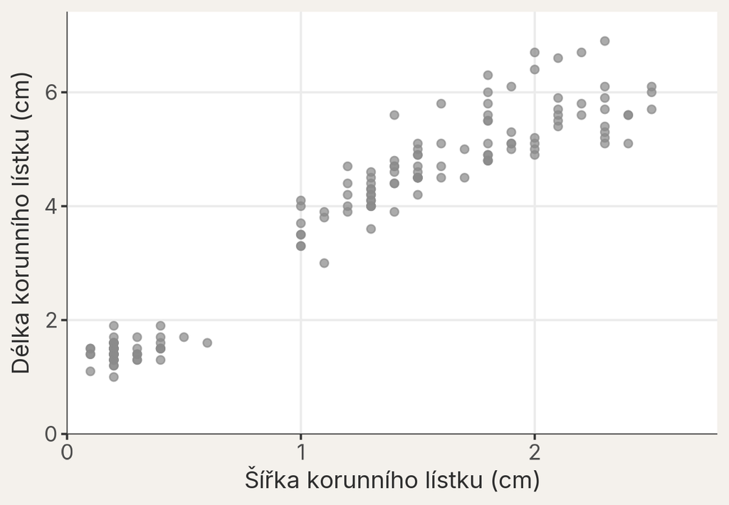

Co vidíme

- vztah je rostoucí
- kolem trendu zůstává variabilita
- jednotlivé květy neleží na jedné přímce

Otázka na velikost změny

O kolik se liší odhadnutá délka dvou květů, jejichž šířky se liší o 1 cm?

# Co rozhoduje mezi přímkami?

## Která z mnoha přímek vystihuje měření?

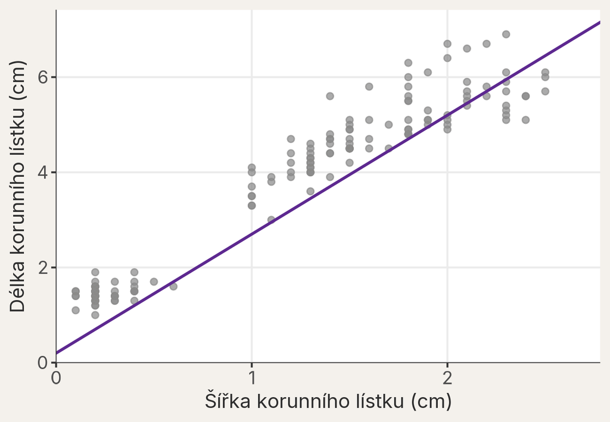

Diskuze se sousedem — 30 s

Sledujte jeden cyklus. Podle čeho byste mezi přímkami rozhodli?

## Kterou ze tří přímek byste vybrali?

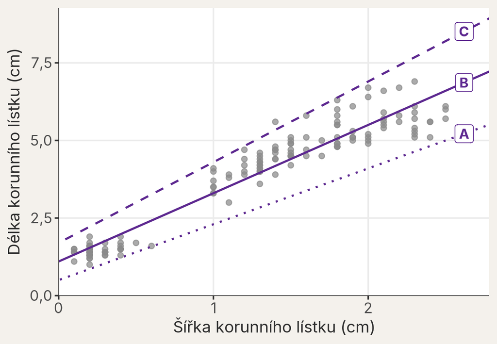

Hlasování

Zvolte A, B, nebo C a napište, podle čeho posuzujete nejlepší přímku.

## Co se změní, když přímku posuneme?

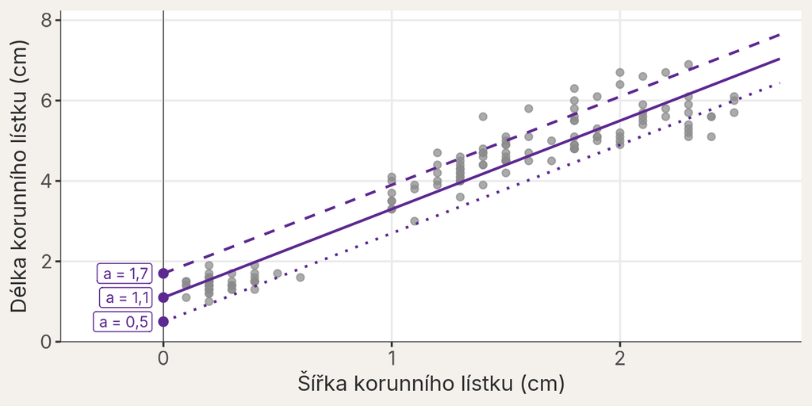

Intercept (a) posouvá přímku nahoru nebo dolů.

## Co se změní, když přímku nakloníme?

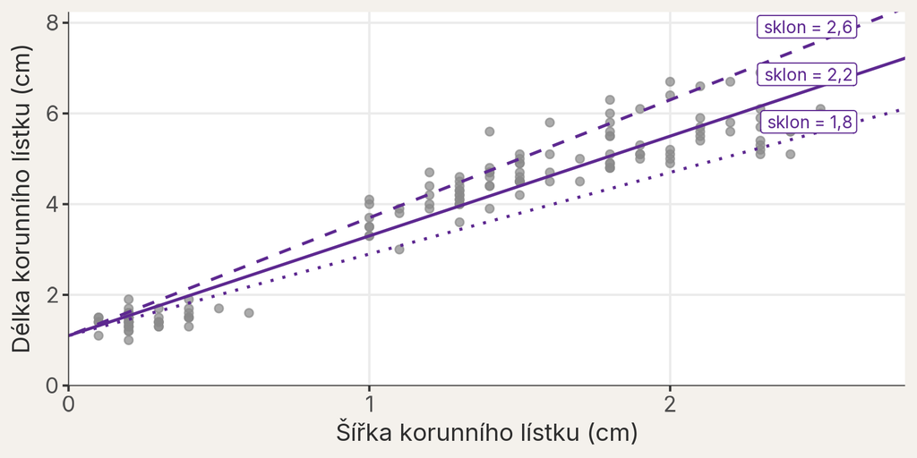

Sklon (b) říká, jak rychle se mění odhadnutá délka s rostoucí šířkou.

## Dvě čísla popíší každou přímku

$$\text{odhadnutá délka}
=
\text{intercept }(a)
+
\text{sklon }(b) \cdot \text{šířka}$$

**intercept ($a$)**

Výška přímky při šířce 0 cm.

**sklon ($b$)**

Rozdíl odhadnutých délek dvou šířek, které se liší o 1 cm.

# Jak daleko je měření od přímky?

## Jeden květ a přímka B

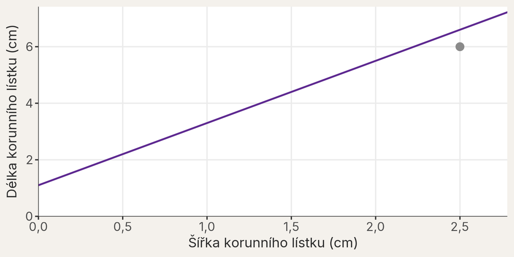

Přímka B · šedý bod = květ 4 z tabulky: šířka **2,5 cm**, naměřená délka **6 cm**

## Odhad přímky pro stejnou šířku

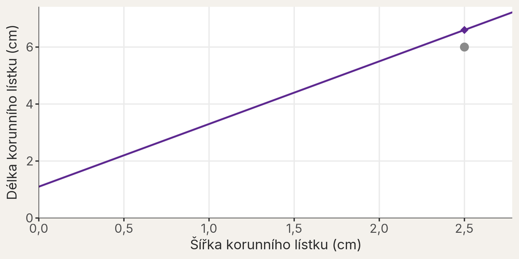

Fialový bod: odhadnutá délka na přímce při stejné šířce.

## Mezi měřením a odhadem zůstává rozdíl

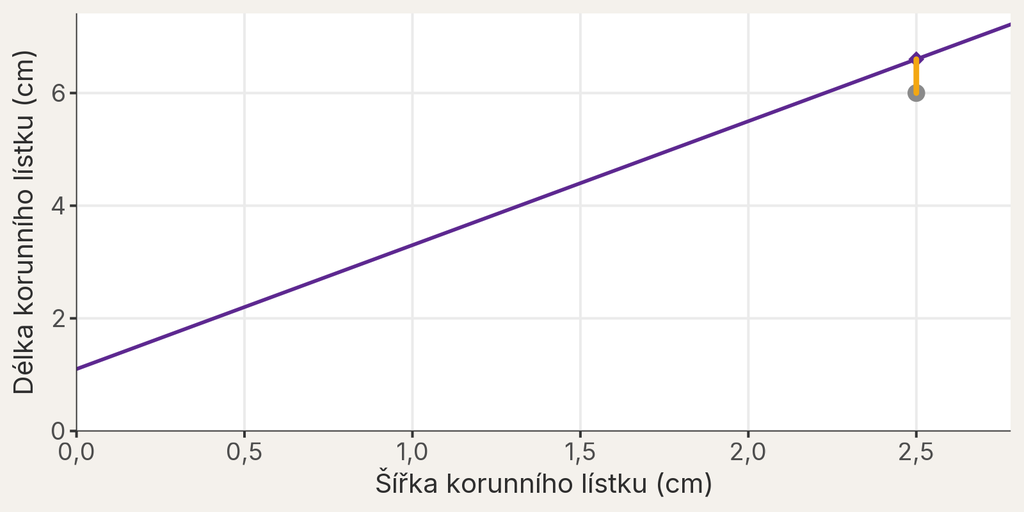

Oranžová úsečka ukazuje residuum: rozdíl mezi naměřenou a odhadnutou délkou.

## Jaké znaménko má residuum?

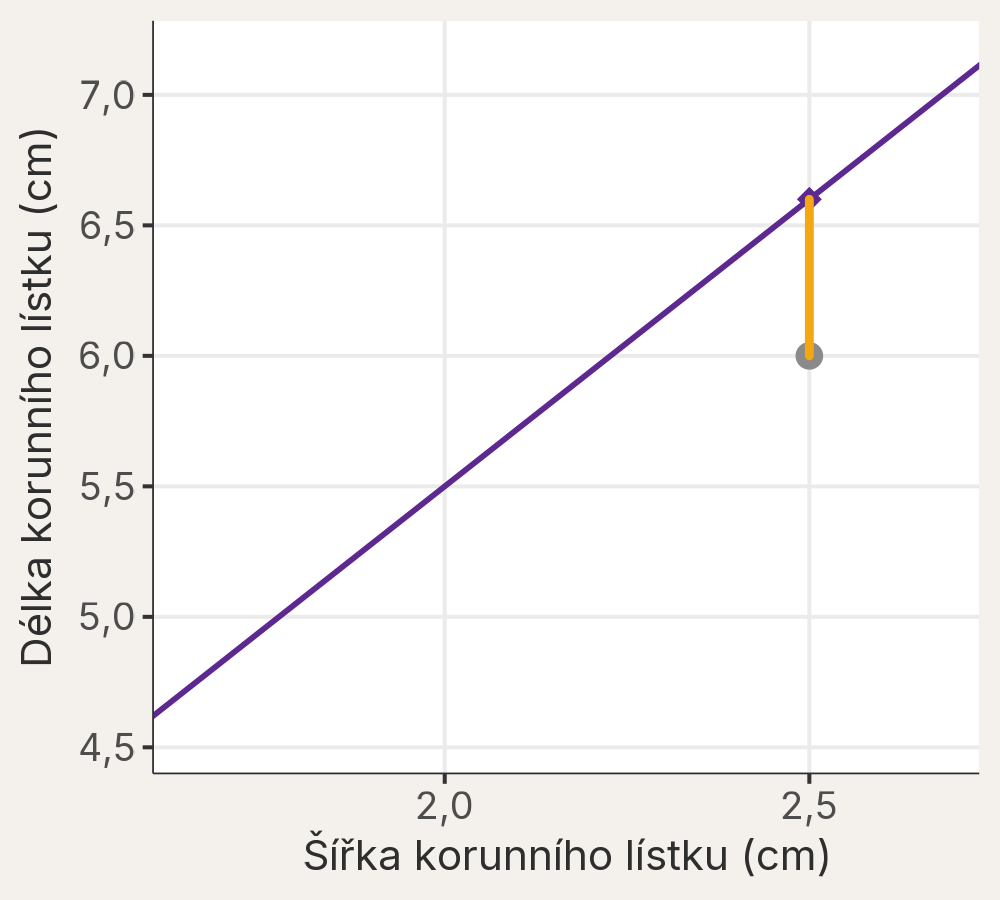

$$\begin{aligned}
\text{residuum} &= \text{naměřená délka} \\
&\quad - \text{odhadnutá délka}
\end{aligned}$$

**A)** kladné

**B)** záporné

**C)** nulové

Zvolte znaménko a zdůvodněte je polohou bodu vůči přímce.

## Odhadnutá délka vybraného květu

Přímka B: **intercept (a) = 1,1 cm** · **sklon (b) = 2,2 cm/cm**

$$\begin{aligned}
\text{odhadnutá délka}
&=
\text{intercept} \\
&\quad +
\text{sklon} \cdot \text{šířka} \\
&=
\text{1,1}
+
\text{2,2} \cdot \text{2,5} \\
&= \text{1,1} + \text{5,5} \\
&=
\text{6,6}\ \text{cm}
\end{aligned}$$

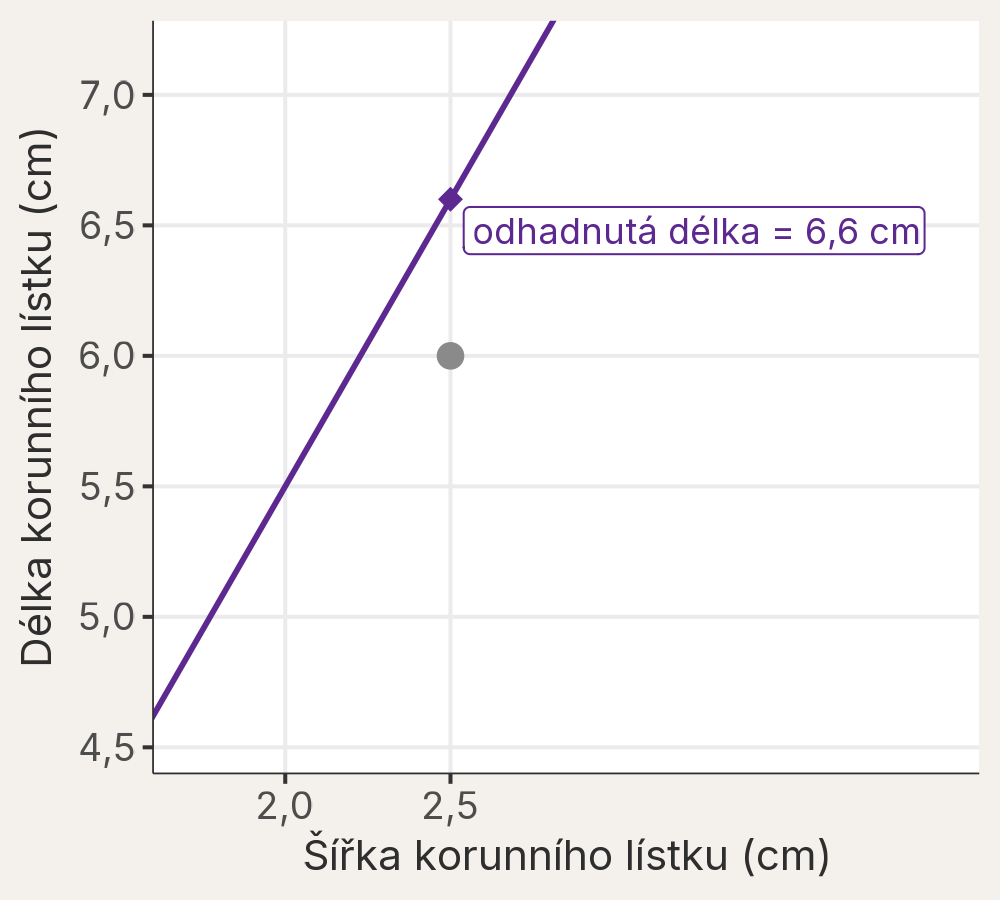

## Residuum vybraného květu

$$\begin{aligned}
\text{residuum}
&=
\text{naměřená délka} \\
&\quad -
\text{odhadnutá délka} \\
&=
\text{6}
-
\text{6,6} \\
&=
\text{−0,6}\ \text{cm}
\end{aligned}$$

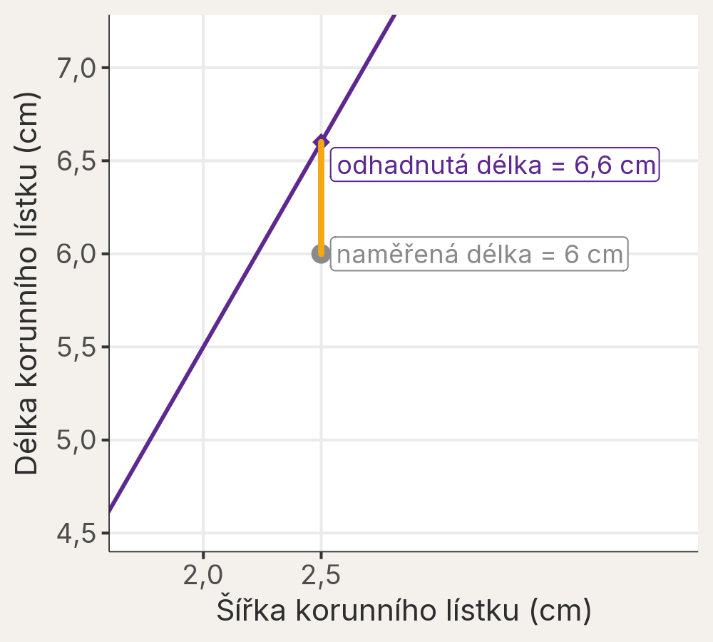

$y_i$ = naměřená délka · $\hat{y}_i$ = odhadnutá délka · $e_i$ = residuum · $i$ = pořadí květu; vše v cm. $e_i = y_i - \hat{y}_i$

## Residua očekáváme i u užitečného modelu

Důležitá myšlenka

Biologická variabilita nezmizí jen proto, že jsme nakreslili modelovou přímku

Model nemusí trefit každý květ přesně. Potřebujeme ale zjistit, zda odchylky působí náhodně, nebo zda v nich zůstává vzor.

## Čtyři květy, stejná přímka

| Květ | Šířka (cm) | Délka (cm) | Odhad (cm) | Residuum (cm) |
| --- | --- | --- | --- | --- |
| 1 | 0,2 | 1,3 | 1,54 | -0,24 |
| 2 | 1,0 | 3,7 | 3,30 | 0,40 |
| 3 | 1,8 | 5,5 | 5,06 | 0,44 |
| 4 | 2,5 | 6,0 | 6,60 | -0,60 |

Součet residuí: **0 cm**. Kladná a záporná residua se vyruší, přestože přímka žádným bodem neprochází.

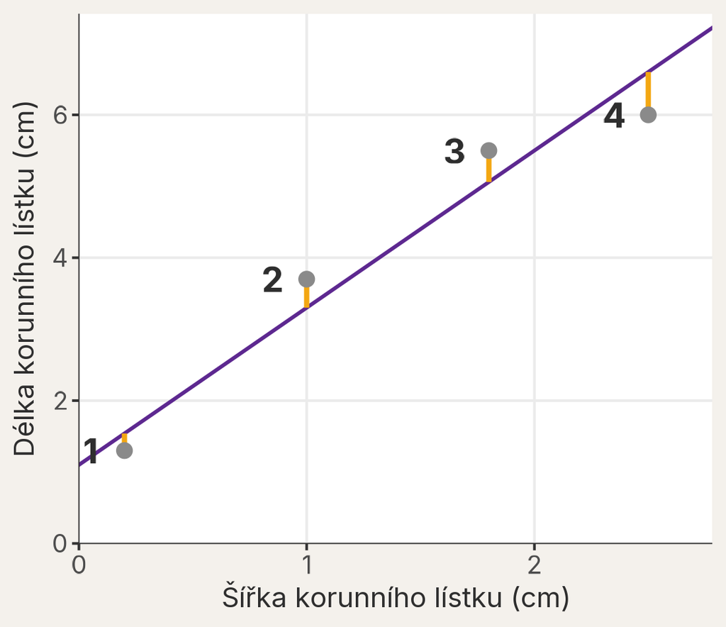

## Jak porovnat celé přímky?

1 · Změřit rozdíl

Pro každý květ určíme residuum.

2 · Odstranit znaménko

Každé residuum umocníme.

3 · Shrnout přímku

Čtverce sečteme do jednoho čísla: SSE.

Menší SSE znamená, že body leží celkově blíže přímce.

## Jiná přímka, jiné vzdálenosti

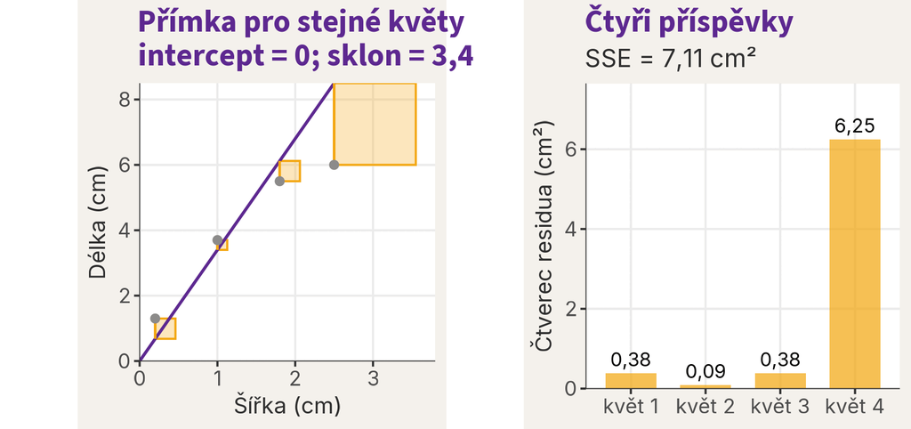

**Sledujte jeden cyklus:** Kdy je celková oranžová plocha nejmenší?

**Stejné květy, jiné parametry přímky:** strana = $|e_i|$ · plocha = $e_i^2$ · součet = **SSE**

## Čtverce residuí čtyř květů

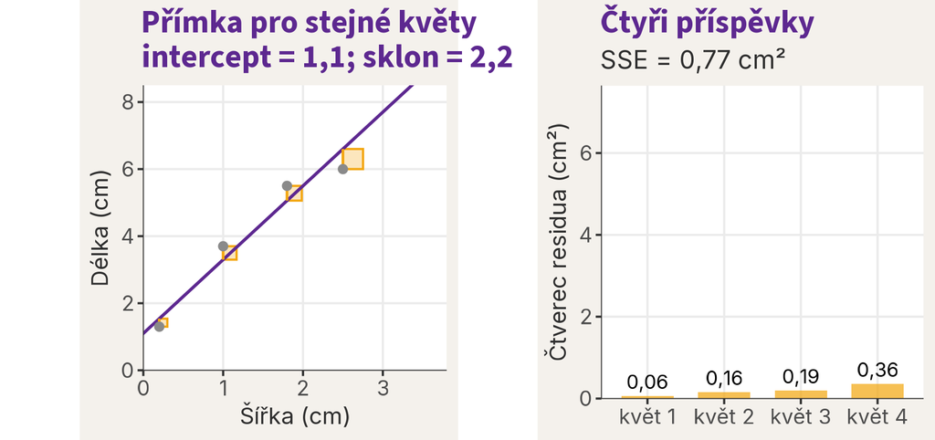

$$\begin{aligned}
\text{SSE} &= (\text{−0,24})^2 + (\text{0,40})^2 \\
&\quad + (\text{0,44})^2 + (\text{−0,60})^2 \\
&\approx \text{0,77}\ \text{cm}^2
\end{aligned}$$

## Stejná residua v R

```r
# Stejná čtyři měření jako v tabulce (cm)
vec_sirka <- c(0.2, 1.0, 1.8, 2.5)
vec_delka <- c(1.3, 3.7, 5.5, 6.0)

# Přímka B: intercept 1.1 cm, sklon 2.2 cm/cm
vec_odhad <- 1.1 + 2.2 * vec_sirka
vec_residua <- vec_delka - vec_odhad

# Prostý součet residuí, zaokrouhlený na setiny cm
round(
  x = sum(vec_residua),
  digits = 2
)
```

```
[1] 0
```

```r
# Součet čtverců residuí (cm²)
sum(vec_residua^2)
```

```
[1] 0.7712
```

Prostý součet residuí je 0 cm, součet jejich čtverců ne. SSE má jednotku cm²; stejný princip použijeme pro všechny květy.

## Která přímka je nejlepší podle těchto dat?

| Přímka | Intercept (cm) | Sklon (cm/cm) | SSE pro 4 květy (cm²) |
| --- | --- | --- | --- |
| A | 0,5 | 1,8 | 6,25 |
| B | 1,1 | 2,2 | 0,77 |
| C | 1,7 | 2,6 | 6,82 |

Vyberte přímku s nejmenším SSE a vysvětlete, co toto číslo shrnuje.

## Počítač hledá nejmenší součet čtverců

Co hledá `lm()`

Intercept a sklon, které dávají nejmenší SSE.

Proč tuto přímku

Přímka leží podle zvoleného pravidla celkově nejblíže naměřeným bodům.

`lm()` použije statistické pravidlo: nejmenší součet čtverců residuí.

# Přímka odhadnutá ze všech květů

## Stejná měření v R

```r
# Načteme tabulku kosatců
data_kosatce <-
  read.csv(file = "data/kosatce.csv")
```

Sloupce souboru

- `sirka_listku`: prediktor (cm)
- `delka_listku`: odezva (cm)
- `druh`, `delka_kalisniho_listku`: zatím mimo model

kosatce.csv: uložte do složky `data` ve svém projektu v R.

## Co obsahuje `data_kosatce`?

```r
# Názvy, typy a první hodnoty sloupců
str(object = data_kosatce)
```

```
'data.frame':   150 obs. of  4 variables:
 $ sirka_listku          : num  0.2 0.2 0.2 0.2 0.2 0.4 0.3 0.2 0.2 0.1 ...
 $ delka_listku          : num  1.4 1.4 1.3 1.5 1.4 1.7 1.4 1.5 1.4 1.5 ...
 $ druh                  : chr  "setosa" "setosa" "setosa" "setosa" ...
 $ delka_kalisniho_listku: num  5.1 4.9 4.7 4.6 5 5.4 4.6 5 4.4 4.9 ...
```

```r
# Počet chybějících hodnot v každém sloupci
colSums(x = is.na(x = data_kosatce))
```

```
          sirka_listku           delka_listku                   druh
                     0                      0                      0
delka_kalisniho_listku
                     0
```

Před modelováním zkontrolujte názvy, typy a chybějící hodnoty. Rozsahy obou měření jsme viděli v úvodní tabulce.

## Jak funkce `lm()` spojuje odezvu a prediktor?

```r
lm(
  formula = odezva ~ prediktor,
  data = data
)
```

Znak `~` čteme: **odezvu vysvětlujeme pomocí prediktoru**.

Vzorec modelu (`formula`)

`delka_listku ~ sirka_listku`

odezva ~ prediktor

Data (`data`)

`data_kosatce`: tabulka se všemi 150 květy

## Jaké koeficienty model odhadne?

Odhadněte předem

Bude odhadnutý sklon blíž přímce A (1,8), B (2,2), nebo C (2,6)?

```r
mod_listky <-
  lm(
    formula = delka_listku ~ sirka_listku,
    data = data_kosatce
  )
```

```r
coef(object = mod_listky)
```

```
 (Intercept) sirka_listku
    1.083558     2.229940
```

| Parametr | Odhad | Jednotka |
| --- | --- | --- |
| Intercept | 1,08 | cm |
| Sklon | 2,23 | cm/cm |

## Přímka odhadnutá z těchto měření

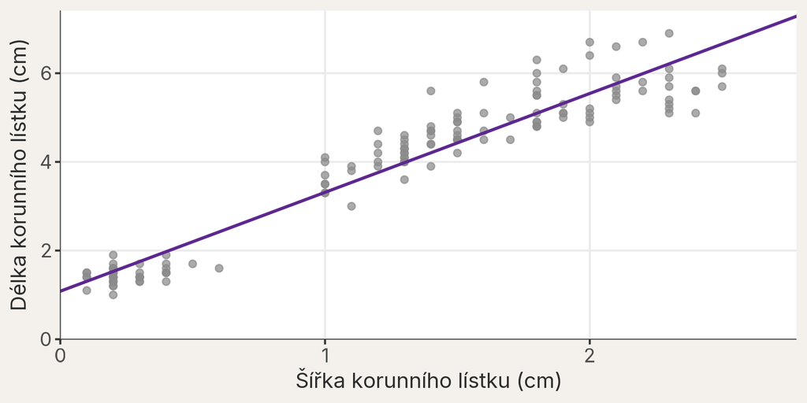

Odhadnutá délka (cm) = 1,08 + 2,23 × šířka (cm)

## Co znamená odhadnutý sklon?

Sklon je **2,23 cm/cm**. Která interpretace je správná?

**A)** Přesný rozdíl délky u každé dvojice květů, jejichž šířky se liší o 1 cm.

**B)** Průměrný rozdíl délky dvou květů, jejichž šířky se liší o 1 cm.

**C)** Podíl variability délky, který vysvětluje šířka korunního lístku.

Zvolte A/B/C. Zdůvodněte, jaké dvě veličiny a jaké jednotky sklon spojuje.

## Co už víme o korunních lístcích?

**Mají širší korunní lístky kosatců také větší délku — a pokud ano, o kolik?**

Co můžeme říct

Ano. Dva květy, jejichž šířky se liší o 1 cm, se podle modelu liší v délce v průměru o **2,23 cm**.

Co zatím nevíme

- Jak přesný je odhad **2,23 cm/cm**?
- Nepřehlíží jedna přímka systematický vzor?

## Souvislost délky a šířky není důkaz příčiny

Biologický závěr

Asociace $\neq$ příčina

Model popisuje vztah v datech. Bez dalšího výzkumného designu neprokazuje, že větší šířka **způsobuje** větší délku.

# Co zůstává mimo přímku?

## Jak jsou residua rozdělená?

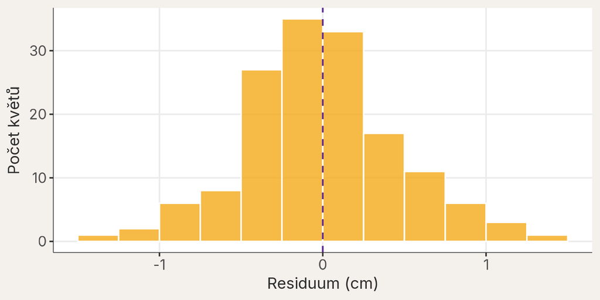

Kde leží většina residuí a jak daleko sahají od nuly?

## Mění se residua podél odhadnuté délky?

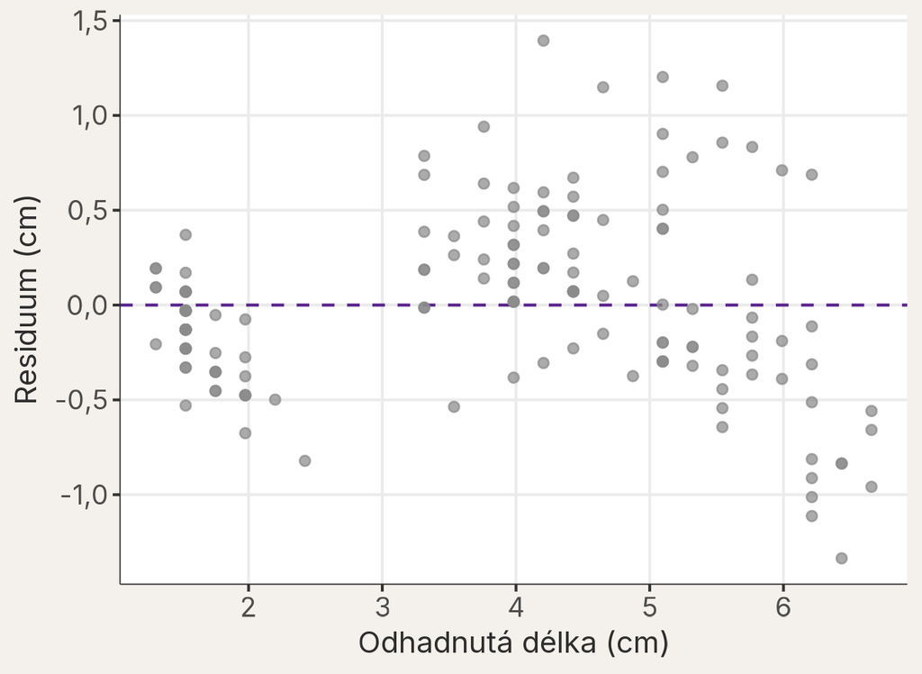

- každý bod je jeden květ
- nad nulou model délku podhodnotil
- pod nulou model délku nadhodnotil
- hledáme neuspořádaný mrak kolem nuly

## Vidíte neuspořádaný mrak, nebo zbývající vzor?

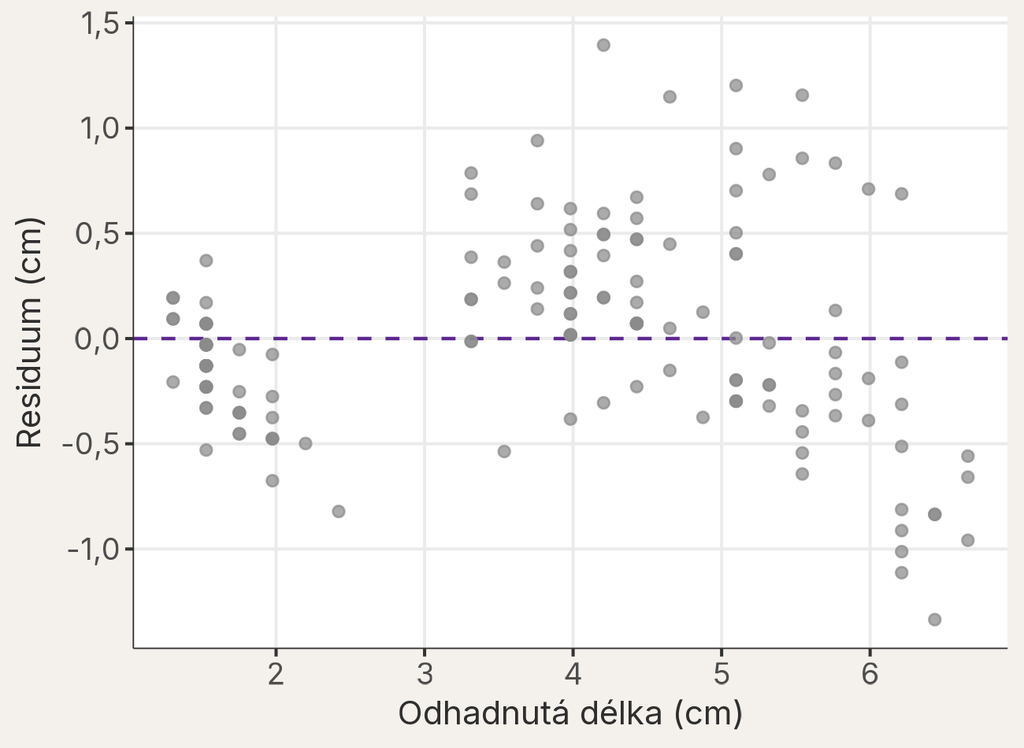

Diskuze se sousedem — 2 min

Najděte jednu oblast s převahou residuí nad nebo pod nulou. Co to říká o odhadované délce?

## Které stopy by nás u přímky zneklidnily?

Schématické vzory; grafy nepředstavují další měření kosatců.

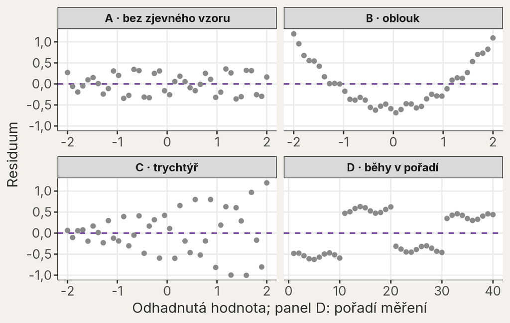

Přiřaďte: tvar vztahu · měnící se rozptýlení · pořadí měření.

B: tvar vztahu · C: měnící se rozptýlení · D: pořadí měření. A model neschvaluje.

## Stejná původní data, ale s druhem

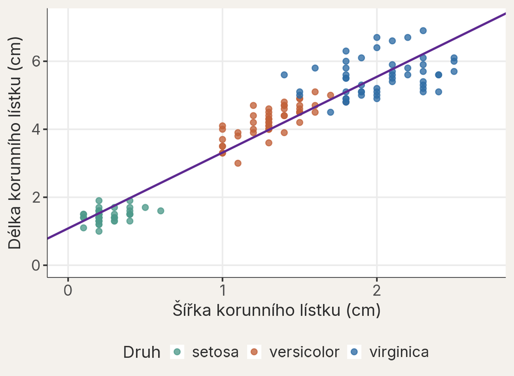

Co vidíte?

Tvoří tři druhy jeden společný mrak kolem přímky, nebo samostatné skupiny?

## Stejná residua, ale s druhem

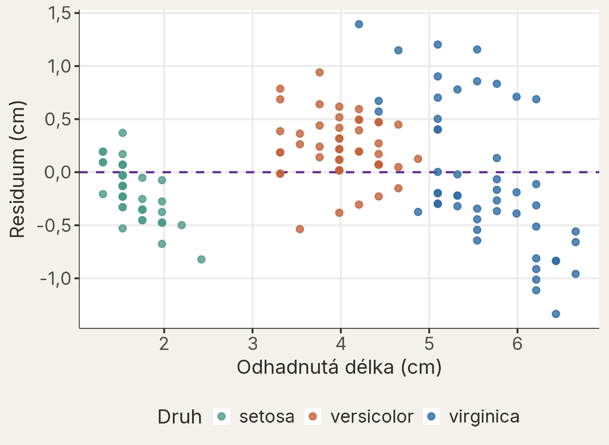

Diskuze se sousedem — 1 min

Který druh model spíše nadhodnocuje a který podhodnocuje? Podle čeho to poznáte?

## Co model neviděl?

Chybějící prediktor

Druh kosatce

Jedna přímka zachytila celkový růst, ale druhy netvoří jeden společný mrak. Jejich struktura proto zůstává v residuích.

*versicolor*: 84 % residuí nad nulou → podhodnocuje · *setosa*: 78 % pod nulou → nadhodnocuje · *virginica*: 64 % pod nulou, hlavně nejširší květy

První model je začátek argumentu, ne jeho automatický konec.

# Závěr

## Shrnutí

- Biologickou otázku převádíme na odezvu a prediktor.
- `lm()` hledá přímku s nejmenším součtem čtverců residuí; sklon je průměrný rozdíl odezvy mezi pozorováními, jejichž prediktor se liší o jednu jednotku.
- Residuum je rozdíl mezi naměřenou a odhadnutou hodnotou; ukazuje, co model u jednotlivých pozorování nevysvětlil.
- Vzor v residuích upozorňuje na chybějící strukturu nebo omezení modelu.

## Co potřebujete vidět, než napíšete „o centimetr širší lístek, o 2,23 cm delší lístek“?

Jaké tři otázky položíte autorovi, který vám ukáže jen sklon 2,23 cm/cm bez grafu?

Řekněte sousedovi jednou větou

Kterou z otázek byste položili jako první, a proč?

Jak přesný je odhad sklonu? Následující lekce přidá nejistotu odhadu.